# data_visualization_project

Ali Abid

2024-10-20

# ASER Pakistan Data Visualization Project

# 1. Introduction

Despite being the fifth most populous country in the world, Pakistan is only able to spend as much as 1.7 percent of its GDP on education. The tumultuous domestic political climate, in conjunction with the global geopolitical landscape, has undeniably resulted in a series of macroeconomic crises within the nation. These crises have unfortunately led to widespread inflation, a rise in poverty, and a profound literacy crisis that poses significant challenges for future generations. A sizable children population (around 26 million) remains out of school which can have devastating impact on the opportunities of the country to grow out of these crises.

In recent times, the World Bank has observed that Pakistan’s Human Capital Index (HCI) has dropped to 0.41, making it lower than other South Asian peers. Hence, as researchers, there is a need for greater critical understanding about rectifying and remedying the problems at hand. Rather than focusing on all-encompassing solutions, more data-driven, targeted approaches are required to provide stability to the educational sector.

# 2. Data

In light of this, the [ASER Pakistan’s 2023 Report](https://aserpakistan.org/report) and its [data set](https://aserpakistan.org/index.php?func=data_statistics) provides valuable, and up to date insights into the household data, school related information, and children’s literacy through testing. The ASER Pakistan works as a private, non-profit think-tank but receives development funding through the government and other international non-governmental organizations to conduct a sample survey across 123 urban districts and 151 rural districts in Pakistan. The 2023 data shows that they reached out to 272,300 children to conduct their foundational literacy and proficiency tests. The ASER data sets used in this assignment and class contain observations of only rural areas of Pakistan. Since the data is collected from a sample of rural areas, the findings are not generalizable to the entire population of Pakistan. Similarly, since the data is merged across three subsets, the number of variables and observations may vary in the cleaning process by removing missing values and other inconsistencies.

# 3. Research Questions

The ASER Pakistan data set provides a wealth of information about the educational landscape in rural Pakistan. In this project, my primary focus is to relate the surveyed children to their households and schools. In this way, we can better understand the relational aspects of household factors and school characteristics that may influence the educational outcomes of children.

The following research questions will be addressed in this project:

1. What is the distribution of children enrolled in government and private schools in rural areas?
2. What is the proportion of co-educational schools versus single-gender schools in rural areas?
3. How does the proportion of psychological impact vary based on the severity of flood impact in rural areas?
4. How does the awareness of climate change influence the proportion of households experiencing an earning impact in rural areas?
5. What is the distribution of arithmetic levels by the medium of instruction for the first five grades in rural areas?

### 3.1 Variables of Interest

The variables of interest for this project include:

| Variable Name | Description |
| --- | --- |
| HHID | Household Identification Number |
| VMAPID | Village/Urban Mapping Identification Number |
| Id | Unique Identifier for Child |
| AREA | Geographic Area (Rural/Urban) |
| RNAME | Region Name |
| DNAME | District Name |
| HouseType | Type of Housing (e.g., Owned, Rented) |
| HouseholdCounter | Number of Household Members |
| EarningMembers | Number of Earning Members in Household |
| Car | Household Car Ownership (Yes/No) |
| MotorCycle | Household Motorcycle Ownership (Yes/No) |
| TravelTime | Time taken to reach school (in minutes) |
| ClimateChange | Awareness of Climate Change (Informed/Uninformed) |
| FloodImpacted | Impact of Flood on Household (Yes/No) |
| EarningImpacted | Impact of Climate Change on Household Earnings (% change) |
| PsychologicalImpacted | Psychological Impact of Climate Change (Substantially/Somewhat) |
| SchoolingAffected | Impact of Climate Change on Schooling (Extremely/Moderately) |
| SchoolType | Type of School (Government/Private) |
| TeachersAppointed | Number of Teachers Appointed |
| TeachersPresent | Number of Teachers Present |
| SingleOrCoEdSchool | School Type (Single-sex/Co-educational) |
| InstructionMedium | Medium of Instruction (English/Urdu/Sindhi) |
| ChildrenEnrolled | Number of Children Enrolled in School |
| ChildrenPresent | Number of Children Present in School |
| VCODES | Village/Urban Codes |
| EducationalStatus | Educational Status of Child (Enrolled/Dropout) |
| SurveyedChildToSchool | Surveyed Child’s School Attendance (Yes/No) |
| Grades | Child’s Current Grade Level |
| InstitutionType | Type of Educational Institution (Government/Private) |
| LocalLangReadingLevel | Child’s Reading Level in Local Language (Beginner/Advanced) |
| ArithmeticLevel | Child’s Arithmetic Level (Basic/Advanced) |
| EnglishReadingLevel | Child’s English Reading Level (Beginner/Advanced) |

# 4. Data Cleaning and Preparation

The data cleaning and preparation process for this project involves loading the three datasets (school, child, and household) into R, renaming some column names to make them consistent, merging them, selecting the relevant columns, filtering out the missing values, making data types consistent such as integer, character or factor, and recoding variables into *CamelCase* for better understanding. The data cleaning and preparation process is crucial for ensuring that the data is ready for analysis and visualization.

### 4.1 Loading the Data

```r
library(tidyverse)
library(readxl)
library(see)
# Loading the three datasets into R
aser_child <- read.csv("ITAASER2023Child.csv")
aser_household <- read.csv("ITAASER2023Household.csv") %>%
  rename(HHID = HouseholdId) %>% # Renaming the HouseholdId column to HHID for merging with the Child Dataset
  rename(VMAPID = VillageMapSurveyId) # Renaming the VillageMapSurveyId column to VMAPID for merging with the School Dataset
aser_school <- read.csv("ITAASER2023School.csv")

glimpse(aser_child)
```

```
## Rows: 214,014
## Columns: 47
## $ Id            <int> 1532002, 1532003, 1532004, 1532005, 1532006, 1532007, 15…
## $ RNAME         <chr> "PUNJAB", "PUNJAB", "PUNJAB", "PUNJAB", "PUNJAB", "PUNJA…
## $ PrvCode       <int> 1, 1, 1, 1, 1, 1, 1, 1, 1, 1, 1, 1, 1, 1, 1, 1, 1, 1, 1,…
## $ DNAME         <chr> "VEHARI", "VEHARI", "VEHARI", "VEHARI", "VEHARI", "VEHAR…
## $ DstCode       <int> 35, 35, 35, 35, 35, 35, 35, 35, 35, 35, 35, 35, 35, 35, …
## $ VCODES        <int> 6578, 6578, 6578, 6578, 6578, 6578, 6578, 6579, 6579, 65…
## $ C03           <int> 11, 7, 4, 4, 12, 8, 7, 14, 11, 7, 15, 13, 10, 5, 9, 7, 5…
## $ C04           <int> 1, 1, NA, 1, 0, 0, 1, 1, 0, 0, 0, 1, 0, 0, 0, 0, 1, NA, …
## $ C05           <int> 3, 3, NA, NA, 3, 3, 3, 3, 3, 3, 3, 3, 3, 3, 3, 3, 3, 3, …
## $ C06           <chr> "7", "2", "", "", "5", "2", "2", "8", "", "", "9", "8", …
## $ C08           <chr> "NULL", "NULL", "NULL", "NULL", "12", "NULL", "NULL", "N…
## $ C09           <chr> "NULL", "NULL", "NULL", "NULL", "NULL", "NULL", "NULL", …
## $ C10           <chr> "7", "3", "ECE", "ECE", "7", "4", "3", "", "7", "3", "11…
```

[output cut: 34 more lines]

```r
summary(aser_child)
```

```
##        Id             RNAME              PrvCode        DNAME
##  Min.   :1532002   Length:214014      Min.   :1.00   Length:214014
##  1st Qu.:2533318   Class :character   1st Qu.:2.00   Class :character
##  Median :2603819   Mode  :character   Median :3.00   Mode  :character
##  Mean   :2377380                      Mean   :2.99
##  3rd Qu.:2657391                      3rd Qu.:4.00
##  Max.   :2764055                      Max.   :7.00
##
##     DstCode           VCODES           C03              C04
##  Min.   :  1.00   Min.   :    1   Min.   : 3.000   Min.   :0.0000
##  1st Qu.: 42.00   1st Qu.: 1461   1st Qu.: 6.000   1st Qu.:0.0000
##  Median : 78.00   Median : 2943   Median : 9.000   Median :0.0000
##  Mean   : 78.46   Mean   : 3825   Mean   : 8.941   Mean   :0.4683
##  3rd Qu.:113.00   3rd Qu.: 4510   3rd Qu.:12.000   3rd Qu.:1.0000
##  Max.   :179.00   Max.   :22818   Max.   :16.000   Max.   :2.0000
##                                   NA's   :758      NA's   :1477
##       C05            C06                C08                C09
##  Min.   :1.000   Length:214014      Length:214014      Length:214014
##  1st Qu.:3.000   Class :character   Class :character   Class :character
##  Median :3.000   Mode  :character   Mode  :character   Mode  :character
##  Mean   :2.611
##  3rd Qu.:3.000
##  Max.   :3.000
##  NA's   :1478
##      C10                 C11             C12             C07
##  Length:214014      Min.   :1.00    Min.   :0.00    Min.   :0.00
##  Class :character   1st Qu.:1.00    1st Qu.:0.00    1st Qu.:0.00
##  Mode  :character   Median :1.00    Median :0.00    Median :0.00
##                     Mean   :1.26    Mean   :0.43    Mean   :0.06
##                     3rd Qu.:1.00    3rd Qu.:1.00    3rd Qu.:0.00
##                     Max.   :4.00    Max.   :1.00    Max.   :1.00
##                     NA's   :46694   NA's   :43307   NA's   :44223
##       C13            C14                 C15             C16
##  Min.   :0.0     Length:214014      Min.   :1.00    Min.   :0.00
##  1st Qu.:0.0     Class :character   1st Qu.:2.00    1st Qu.:1.00
##  Median :0.0     Mode  :character   Median :3.00    Median :1.00
##  Mean   :0.1                        Mean   :3.27    Mean   :0.93
##  3rd Qu.:0.0                        3rd Qu.:5.00    3rd Qu.:1.00
##  Max.   :1.0                        Max.   :5.00    Max.   :1.00
##  NA's   :45575                      NA's   :61025   NA's   :165959
```

[output cut: 41 more lines]

```
##  Min.   :1       Min.   :1        Min.   :1        Min.   :1
##  1st Qu.:1       1st Qu.:1        1st Qu.:1        1st Qu.:1
##  Median :1       Median :1        Median :1        Median :1
##  Mean   :1       Mean   :1        Mean   :1        Mean   :1
##  3rd Qu.:1       3rd Qu.:1        3rd Qu.:1        3rd Qu.:1
##  Max.   :1       Max.   :1        Max.   :1        Max.   :1
##  NA's   :67401   NA's   :103281   NA's   :101573   NA's   :98725
##       BCG            AREA                HHID
##  Min.   :1       Length:214014      Min.   :1365063
##  1st Qu.:1       Class :character   1st Qu.:2365537
##  Median :1       Mode  :character   Median :2404322
##  Mean   :1                          Mean   :2169913
##  3rd Qu.:1                          3rd Qu.:2423130
##  Max.   :1                          Max.   :2500560
##  NA's   :96075
```

```r
str(aser_household)
```

```
## 'data.frame':    89602 obs. of  58 variables:
##  $ HHID                            : int  1411380 1374733 1375159 1375161 1375166 1375168 1375173 1375214 1375217 1375221 ...
##  $ VMAPID                          : int  30042 30055 30055 30055 30055 30055 30055 30055 30055 30055 ...
##  $ HouseholdCounter                : int  20 20 2 3 4 5 6 7 8 9 ...
##  $ IsFamilyHead                    : int  0 0 0 0 0 0 0 0 0 0 ...
##  $ Gender                          : int  1 1 1 NA NA 2 1 1 NA NA ...
##  $ MaleMembers                     : int  3 4 4 6 1 3 1 3 6 4 ...
##  $ FemaleMembers                   : int  2 2 2 2 1 1 1 1 3 3 ...
##  $ EarningMembers                  : int  2 3 1 3 1 1 1 1 2 1 ...
##  $ EarningMembersChild             : int  NA NA NA NA NA NA NA NA NA NA ...
##  $ HouseType                       : int  2 1 2 2 1 2 1 1 2 2 ...
##  $ IsHouseOwned                    : int  1 0 1 0 0 0 0 0 0 0 ...
##  $ IsElectricityConnectionAvailable: int  1 1 1 1 1 1 1 1 1 1 ...
##  $ IsTVAvailable                   : int  0 0 0 0 0 0 0 0 0 0 ...
##  $ IsRadioAvailable                : int  0 0 0 0 0 0 0 0 0 0 ...
```

[output cut: 44 more lines]

```r
glimpse(aser_household)
```

```
## Rows: 89,602
## Columns: 58
## $ HHID                             <int> 1411380, 1374733, 1375159, 1375161, 1…
## $ VMAPID                           <int> 30042, 30055, 30055, 30055, 30055, 30…
## $ HouseholdCounter                 <int> 20, 20, 2, 3, 4, 5, 6, 7, 8, 9, 11, 1…
## $ IsFamilyHead                     <int> 0, 0, 0, 0, 0, 0, 0, 0, 0, 0, 0, 0, 0…
## $ Gender                           <int> 1, 1, 1, NA, NA, 2, 1, 1, NA, NA, 2, …
## $ MaleMembers                      <int> 3, 4, 4, 6, 1, 3, 1, 3, 6, 4, 3, 1, 2…
## $ FemaleMembers                    <int> 2, 2, 2, 2, 1, 1, 1, 1, 3, 3, 2, 1, 2…
## $ EarningMembers                   <int> 2, 3, 1, 3, 1, 1, 1, 1, 2, 1, 1, 1, 2…
## $ EarningMembersChild              <int> NA, NA, NA, NA, NA, NA, NA, NA, NA, N…
## $ HouseType                        <int> 2, 1, 2, 2, 1, 2, 1, 1, 2, 2, 1, 2, 1…
## $ IsHouseOwned                     <int> 1, 0, 1, 0, 0, 0, 0, 0, 0, 0, 0, 0, 0…
## $ IsElectricityConnectionAvailable <int> 1, 1, 1, 1, 1, 1, 1, 1, 1, 1, 1, 1, 1…
## $ IsTVAvailable                    <int> 0, 0, 0, 0, 0, 0, 0, 0, 0, 0, 0, 0, 0…
```

[output cut: 45 more lines]

```r
glimpse(aser_school)
```

```
## Rows: 6,095
## Columns: 137
## $ SYEAR     <int> 2023, 2023, 2023, 2023, 2023, 2023, 2023, 2023, 2023, 2023, …
## $ AREA      <int> 2, 2, 2, 2, 2, 2, 2, 2, 2, 2, 2, 2, 2, 2, 2, 2, 2, 2, 2, 2, …
## $ VMAPID    <int> 336803, 316762, 336753, 336771, 336805, 316754, 336758, 3367…
## $ RNAME     <chr> "AZAD JAMMU AND KASHMIR                            ", "AZAD …
## $ DNAME     <chr> "BAGH", "BAGH", "BAGH", "BAGH", "BAGH", "BAGH", "BAGH", "BAG…
## $ VlgId     <int> 5010, 5019, 5020, 5001, 5009, 5003, 5004, 5016, 5006, 5011, …
## $ VlgCode   <chr> "10", "19", "20", "1", "9", "3", "4", "16", "6", "11", "7", …
## $ SID       <int> 1, 2, 3, 4, 5, 6, 7, 8, 9, 10, 11, 12, 13, 14, 15, 16, 17, 1…
## $ STYPE     <int> 1, 1, 1, 1, 1, 1, 1, 1, 1, 1, 1, 1, 1, 1, 1, 1, 1, 1, 1, 1, …
## $ S006      <int> NA, NA, NA, NA, NA, NA, NA, NA, NA, NA, NA, NA, NA, NA, NA, …
## $ S00       <int> 4, 3, 3, 1, 2, 1, 4, 1, 2, 2, 3, 1, 3, 2, 2, 1, 1, 2, 1, 2, …
## $ S00a      <chr> "N TO 5", "", "", "", "", "", "", "", "", "", "ECE- 10", "NU…
## $ S001      <int> 1, 2, 2, 1, 1, 1, 1, 2, 1, 1, 1, 1, 2, 1, 2, 1, 1, 1, 1, 2, …
```

[output cut: 124 more lines]

```r
summary(aser_school)
```

```
##      SYEAR           AREA       VMAPID          RNAME
##  Min.   :2023   Min.   :2   Min.   : 30271   Length:6095
##  1st Qu.:2023   1st Qu.:2   1st Qu.:265637   Class :character
##  Median :2023   Median :2   Median :284956   Mode  :character
##  Mean   :2023   Mean   :2   Mean   :284882
##  3rd Qu.:2023   3rd Qu.:2   3rd Qu.:286091
##  Max.   :2023   Max.   :2   Max.   :337126
##
##     DNAME               VlgId         VlgCode               SID
##  Length:6095        Min.   :  146   Length:6095        Min.   :   1
##  Class :character   1st Qu.: 5924   Class :character   1st Qu.:1524
##  Mode  :character   Median : 7075   Mode  :character   Median :3050
##                     Mean   : 7444                      Mean   :3049
##                     3rd Qu.: 8310                      3rd Qu.:4574
##                     Max.   :22818                      Max.   :6097
##
##      STYPE            S006            S00            S00a
##  Min.   :1.000   Min.   :1.000   Min.   :1.000   Length:6095
##  1st Qu.:1.000   1st Qu.:1.000   1st Qu.:1.000   Class :character
##  Median :1.000   Median :1.000   Median :2.000   Mode  :character
##  Mean   :1.275   Mean   :1.166   Mean   :2.051
##  3rd Qu.:2.000   3rd Qu.:1.000   3rd Qu.:3.000
##  Max.   :2.000   Max.   :4.000   Max.   :4.000
##                  NA's   :5481
##       S001            S002          S002a               S002Y
##  Min.   :1.000   Min.   :1.000   Length:6095        Min.   :1829
##  1st Qu.:1.000   1st Qu.:1.000   Class :character   1st Qu.:1982
##  Median :1.000   Median :2.000   Mode  :character   Median :1999
##  Mean   :1.625   Mean   :1.905                      Mean   :1993
##  3rd Qu.:2.000   3rd Qu.:2.000                      3rd Qu.:2011
##  Max.   :3.000   Max.   :4.000                      Max.   :2023
##                  NA's   :210                        NA's   :895
##      S007E            S007P            S03a1           S03b1
##  Min.   :  10.0   Min.   :   2.0   Min.   :0.0000   Length:6095
##  1st Qu.:  85.0   1st Qu.:  69.0   1st Qu.:0.0000   Class :character
##  Median : 154.0   Median : 134.0   Median :0.0000   Mode  :character
##  Mean   : 203.1   Mean   : 181.2   Mean   :0.4929
##  3rd Qu.: 250.0   3rd Qu.: 224.0   3rd Qu.:1.0000
##  Max.   :2342.0   Max.   :2196.0   Max.   :1.0000
##                                    NA's   :283
```

[output cut: 217 more lines]

```
##  Min.   :1900   Min.   :1.000   Min.   :0.0000   Min.   :0.000
##  1st Qu.:1997   1st Qu.:1.000   1st Qu.:0.0000   1st Qu.:2.000
##  Median :2011   Median :1.000   Median :1.0000   Median :2.000
##  Mean   :2004   Mean   :2.213   Mean   :0.6132   Mean   :2.453
##  3rd Qu.:2019   3rd Qu.:3.000   3rd Qu.:1.0000   3rd Qu.:3.000
##  Max.   :2023   Max.   :5.000   Max.   :1.0000   Max.   :5.000
##  NA's   :3723   NA's   :141     NA's   :837      NA's   :963
##      S013d           S013e            SURID
##  Min.   :0.000   Min.   :  1.00   Min.   : 10054
##  1st Qu.:0.000   1st Qu.:  7.00   1st Qu.:191705
##  Median :0.000   Median : 20.00   Median :264669
##  Mean   :0.228   Mean   : 22.91   Mean   :197659
##  3rd Qu.:0.000   3rd Qu.: 30.00   3rd Qu.:265781
##  Max.   :1.000   Max.   :132.00   Max.   :317067
##  NA's   :982     NA's   :4929
```

```r
child_house <- left_join(aser_child, aser_household, by = c("HHID")) # Merging the Child and Household Datasets by HHID which stands for the unique Household ID

child_house_school <- left_join(child_house, aser_school, by = c("VMAPID")) # Merging the Child-Household Dataset that was created above with the School Dataset by VMAPID which stands for the unique Village Map Survey ID
glimpse(child_house_school)
```

```
## Rows: 290,459
## Columns: 240
## $ Id                               <int> 1532002, 1532002, 1532003, 1532003, 1…
## $ RNAME.x                          <chr> "PUNJAB", "PUNJAB", "PUNJAB", "PUNJAB…
## $ PrvCode                          <int> 1, 1, 1, 1, 1, 1, 1, 1, 1, 1, 1, 1, 1…
## $ DNAME.x                          <chr> "VEHARI", "VEHARI", "VEHARI", "VEHARI…
## $ DstCode                          <int> 35, 35, 35, 35, 35, 35, 35, 35, 35, 3…
## $ VCODES                           <int> 6578, 6578, 6578, 6578, 6578, 6578, 6…
## $ C03                              <int> 11, 11, 7, 7, 4, 4, 4, 4, 12, 12, 8, …
## $ C04                              <int> 1, 1, 1, 1, NA, NA, 1, 1, 0, 0, 0, 0,…
## $ C05                              <int> 3, 3, 3, 3, NA, NA, NA, NA, 3, 3, 3, …
## $ C06                              <chr> "7", "7", "2", "2", "", "", "", "", "…
## $ C08                              <chr> "NULL", "NULL", "NULL", "NULL", "NULL…
## $ C09                              <chr> "NULL", "NULL", "NULL", "NULL", "NULL…
## $ C10                              <chr> "7", "7", "3", "3", "ECE", "ECE", "EC…
```

[output cut: 227 more lines]

```r
summary(child_house_school)
```

```
##        Id            RNAME.x             PrvCode        DNAME.x
##  Min.   :1532002   Length:290459      Min.   :1.000   Length:290459
##  1st Qu.:1617121   Class :character   1st Qu.:2.000   Class :character
##  Median :2599351   Mode  :character   Median :3.000   Mode  :character
##  Mean   :2368619                      Mean   :3.073
##  3rd Qu.:2655893                      3rd Qu.:4.000
##  Max.   :2764055                      Max.   :7.000
##
##     DstCode           VCODES           C03              C04
##  Min.   :  1.00   Min.   :    1   Min.   : 3.000   Min.   :0.0000
##  1st Qu.: 39.00   1st Qu.: 1200   1st Qu.: 6.000   1st Qu.:0.0000
##  Median : 80.00   Median : 2873   Median : 9.000   Median :0.0000
##  Mean   : 79.98   Mean   : 3727   Mean   : 9.062   Mean   :0.4695
##  3rd Qu.:118.00   3rd Qu.: 5559   3rd Qu.:12.000   3rd Qu.:1.0000
##  Max.   :179.00   Max.   :22818   Max.   :16.000   Max.   :2.0000
##                                   NA's   :943      NA's   :1958
##       C05            C06                C08                C09
##  Min.   :1.000   Length:290459      Length:290459      Length:290459
##  1st Qu.:3.000   Class :character   Class :character   Class :character
##  Median :3.000   Mode  :character   Mode  :character   Mode  :character
##  Mean   :2.638
##  3rd Qu.:3.000
##  Max.   :3.000
##  NA's   :2088
##      C10                 C11             C12             C07
##  Length:290459      Min.   :1.0     Min.   :0.00    Min.   :0.00
##  Class :character   1st Qu.:1.0     1st Qu.:0.00    1st Qu.:0.00
##  Mode  :character   Median :1.0     Median :0.00    Median :0.00
##                     Mean   :1.3     Mean   :0.42    Mean   :0.06
##                     3rd Qu.:2.0     3rd Qu.:1.00    3rd Qu.:0.00
##                     Max.   :4.0     Max.   :1.00    Max.   :1.00
##                     NA's   :59255   NA's   :54015   NA's   :55772
##       C13            C14                 C15             C16
##  Min.   :0.00    Length:290459      Min.   :1.00    Min.   :0.00
##  1st Qu.:0.00    Class :character   1st Qu.:2.00    1st Qu.:1.00
##  Median :0.00    Mode  :character   Median :3.00    Median :1.00
##  Mean   :0.11                       Mean   :3.36    Mean   :0.93
##  3rd Qu.:0.00                       3rd Qu.:5.00    3rd Qu.:1.00
##  Max.   :1.00                       Max.   :5.00    Max.   :1.00
##  NA's   :57375                      NA's   :79323   NA's   :218801
```

[output cut: 433 more lines]

```
##  Min.   :0.0     Min.   :0.00    Min.   :0.00    Min.   :  1.0
##  1st Qu.:0.0     1st Qu.:2.00    1st Qu.:0.00    1st Qu.:  8.0
##  Median :1.0     Median :2.00    Median :0.00    Median : 20.0
##  Mean   :0.6     Mean   :2.48    Mean   :0.27    Mean   : 22.6
##  3rd Qu.:1.0     3rd Qu.:3.00    3rd Qu.:1.00    3rd Qu.: 26.0
##  Max.   :1.0     Max.   :5.00    Max.   :1.00    Max.   :132.0
##  NA's   :46505   NA's   :50837   NA's   :53069   NA's   :227449
##      SURID
##  Min.   : 10054
##  1st Qu.:192039
##  Median :264842
##  Mean   :212370
##  3rd Qu.:265953
##  Max.   :317067
##  NA's   :1157
```

```r
head(child_house_school)
```

```
##        Id RNAME.x PrvCode DNAME.x DstCode VCODES C03 C04 C05 C06  C08  C09 C10
## 1 1532002  PUNJAB       1  VEHARI      35   6578  11   1   3   7 NULL NULL   7
## 2 1532002  PUNJAB       1  VEHARI      35   6578  11   1   3   7 NULL NULL   7
## 3 1532003  PUNJAB       1  VEHARI      35   6578   7   1   3   2 NULL NULL   3
## 4 1532003  PUNJAB       1  VEHARI      35   6578   7   1   3   2 NULL NULL   3
## 5 1532004  PUNJAB       1  VEHARI      35   6578   4  NA  NA     NULL NULL ECE
## 6 1532004  PUNJAB       1  VEHARI      35   6578   4  NA  NA     NULL NULL ECE
##   C11 C12 C07 C13  C14 C15 C16 B17 C18 C19 C23 C24 C25 C20 C21 C22 C26a C26b
## 1   1   0   0   1  500   3  NA  NA   1   7   1   0   0   4   1  NA    0    1
## 2   1   0   0   1  500   3  NA  NA   1   7   1   0   0   4   1  NA    0    1
## 3   2   0   0   1  300   2  NA  NA   1   5   1   0   0   3  NA  NA   NA   NA
## 4   2   0   0   1  300   2  NA  NA   1   5   1   0   0   3  NA  NA   NA   NA
## 5  NA   0   0   0 NULL  NA  NA  NA  NA  NA  NA  NA  NA  NA  NA  NA   NA   NA
## 6  NA   0   0   0 NULL  NA  NA  NA  NA  NA  NA  NA  NA  NA  NA  NA   NA   NA
##   C27 PRID ICH01     ICH02 ICH03 ICH05 BasicVaccines Allergies C28 Polio
```

[output cut: 195 more lines]

```r
child_house_school <- child_house_school %>%
  select(-c(RNAME.x)) %>% # Removing the RNAME.x column as it is redundant and not needed
  rename(RNAME = RNAME.y) %>% # Renaming the RNAME.y column to RNAME for better understanding
  select(-c(DNAME.x)) %>% # Removing the DNAME.x column as it is redundant and not needed
  rename(DNAME = DNAME.y) # Renaming the DNAME.y column to DNAME for better understanding

child_house_school <- child_house_school %>%
  select(-c(AREA.x)) %>% # Removing the AREA.x column as it is redundant and not needed
  rename(AREA = AREA.y) # Renaming the AREA.y column to AREA for better understanding

colnames(child_house_school) # Checking the column names of the final dataset
```

```
##   [1] "Id"                               "PrvCode"
##   [3] "DstCode"                          "VCODES"
##   [5] "C03"                              "C04"
##   [7] "C05"                              "C06"
##   [9] "C08"                              "C09"
##  [11] "C10"                              "C11"
##  [13] "C12"                              "C07"
##  [15] "C13"                              "C14"
##  [17] "C15"                              "C16"
##  [19] "B17"                              "C18"
##  [21] "C19"                              "C23"
##  [23] "C24"                              "C25"
##  [25] "C20"                              "C21"
##  [27] "C22"                              "C26a"
##  [29] "C26b"                             "C27"
```

[output cut: 104 more lines]

### 4.2 Selecting the Required Columns

```r
# --- 1. Selecting Relevant Variables from Household-Level, Child-Level, and School-Level Observations ---
child_house_school <- child_house_school %>%
  select(
    # Dataset Identifiers
    HHID, VMAPID, Id, AREA, RNAME, DNAME,

    # Household Characteristics
    HouseType, HouseholdCounter, EarningMembers, Car, MotorCycle,

    # Time to school
    TravelTime,

    # Climate Change Impact
    ClimateChange, FloodImpacted, EarningImpacted, PsychologicalImpacted, SchoolingAffected,

    # School Characteristics - SchoolType, TeachersAppointed, TeachersPresent, SingleOrCoEdSchool, InstructionMedium, ChildrenEnrolled, ChildrenPresent
    STYPE, S008TA, S008TP, S001, S002, S007E, S007P,

    # Child Characteristics - EducationalStatus, Grades, InstitutionType, LocalLangReadingLevel, ArithmeticLevel, EnglishReadingLevel
    VCODES, C05, C12, C10, C11, C15, C19, C20
  ) %>%
  rename(
    # School Characteristics - SchoolType, TeachersAppointed, TeachersPresent, SingleOrCoEdSchool, InstructionMedium, ChildrenEnrolled, ChildrenPresent
    SchoolType = STYPE, TeachersAppointed = S008TA, TeachersPresent = S008TP, SingleOrCoEdSchool = S001, InstructionMedium = S002, ChildrenEnrolled = S007E, ChildrenPresent = S007P,

    # Child Characteristics - EducationalStatus, Grades, InstitutionType, LocalLangReadingLevel, ArithmeticLevel, EnglishReadingLevel
    EducationalStatus = C05, Grades = C10, SurveyedChildToSchool = C12, InstitutionType = C11, LocalLangReadingLevel = C15, ArithmeticLevel = C19, EnglishReadingLevel = C20

  )
```

### 4.3 Filtering Out Values

```r
# --- 1. Filter by NAs and Replacing Some NA Values with 0 where applies ---
child_house_school_filtered <- child_house_school %>%
  filter(!is.na(HouseType), !is.na(HouseholdCounter), !is.na(EarningMembers), !is.na(Car), !is.na(MotorCycle), !is.na(TravelTime), !is.na(ClimateChange), !is.na(FloodImpacted), !is.na(EarningImpacted), !is.na(PsychologicalImpacted), !is.na(SchoolingAffected)) %>%
  mutate(
  TeachersAppointed = replace(TeachersAppointed, is.na(TeachersAppointed), 0),
  TeachersPresent = replace(TeachersPresent, is.na(TeachersPresent), 0),
  SchoolType = replace(SchoolType, is.na(SchoolType), 0),
  SingleOrCoEdSchool = replace(SingleOrCoEdSchool, is.na(SingleOrCoEdSchool), 0),
  InstructionMedium = replace(InstructionMedium, is.na(InstructionMedium), 0),
  ChildrenEnrolled = replace(ChildrenEnrolled, is.na(ChildrenEnrolled), 0),
  ChildrenPresent = replace(ChildrenPresent, is.na(ChildrenPresent), 0)
)

# --- 2. Filtering Data Based on Whether the Child Went to Surveyed School or Not  ---

# This is an important relational step as the data contains observations where the child was surveyed but the school was not surveyed and vice versa. Hence, we want to focus on understanding the relational aspect where each observation corresponds to the other observation.

child_house_school_filtered <- child_house_school_filtered %>%
  filter((SurveyedChildToSchool != 0)) # Filtering out only those children who were surveyed and their schools were surveyed as well
```

### 4.4 Making Data Types Consistent

```r
child_house_school_filtered <- child_house_school_filtered %>%
  mutate_if(is.character, as.factor) %>% # Convert character columns to factors
  mutate_if(is.numeric, as.integer) # Convert numeric columns to integers
```

### 4.5 Recoding Variables

```r
# Recoding the SchoolType, SingleOrCoEdSchool, InstructionMedium, EducationalStatus, Grades InstitutionType, ClimateChange, FloodImpacted, EarningImpacted, PsychologicalImpacted, SchoolingAffected, LocalLangReadingLevel, ArithmeticLevel, EnglishReadingLevel, HouseType variables to make them more understandable

child_house_school_filtered <- child_house_school_filtered %>%
  mutate(
    SchoolType = recode(SchoolType, "1" = "Government", "2" = "Private"),
    SchoolType = as.factor(SchoolType)
    ) %>%
  mutate(
    SingleOrCoEdSchool = recode(SingleOrCoEdSchool, "1" = "Boys and Girls School", "2" = "Girls School", "3" = "Boys School"),
    SingleOrCoEdSchool = as.factor(SingleOrCoEdSchool)
  ) %>%
  mutate(
    InstructionMedium = recode(InstructionMedium, "1" = "English Medium", "2" = "Urdu Medium", "3" = "Sindhi Medium", "4" = "Others"),
    InstructionMedium = as.factor(InstructionMedium)
  ) %>%
  mutate(
    EducationalStatus = recode(EducationalStatus, "1" = "Never Enrolled", "2" = "Drop Out", "3" = "Currently Enrolled"),
    EducationalStatus = as.factor(EducationalStatus)
  ) %>%
  mutate(
    Grades = recode(Grades, "1" = "Grade 1", "2" = "Grade 2", "3" = "Grade 3", "4" = "Grade 4", "5" = "Grade 5", "6" = "Grade 6", "7" = "Grade 7", "8" = "Grade 8", "9" = "Grade 9", "10" = "Grade 10", "11" = "Grade 11", "12" = "Grade 12", "ECE" = "Early Childhood Education"),
    Grades = as.factor(Grades)
  ) %>%
  mutate(
    InstitutionType = recode(InstitutionType, "1" = "Government School", "2" = "Private School", "3" = "Madrassah", "4" = "Non-Formal Education"),
    InstitutionType = as.factor(InstitutionType)
  ) %>%
  mutate(
    ClimateChange = recode(ClimateChange, "1" = "Informed", "2" = "Don't Know", "3" = "Uninformed"),
    ClimateChange = as.factor(ClimateChange)
  ) %>%
  mutate(
    FloodImpacted = recode(FloodImpacted, "1" = "Yes, significantly", "2" = "Yes, moderately", "3" = "No, not affected"),
    FloodImpacted = as.factor(FloodImpacted)
  ) %>%
  mutate(
    EarningImpacted = recode(EarningImpacted, "1" = "Less than 10%", "2" = "Between 11% - 25%", "3" = "Between 26% - 50%", "4" = "More than 50%", "5" = "Not Affected"),
    EarningImpacted = as.factor(EarningImpacted)
  ) %>%
  mutate(
    PsychologicalImpacted = recode(PsychologicalImpacted, "1" = "Substantially", "2" = "Somewhat Affected", "3" = "Not Affected", "4" = "Not Affected"),
    PsychologicalImpacted = as.factor(PsychologicalImpacted)
  ) %>%
  mutate(
    SchoolingAffected = recode(SchoolingAffected, "1" = "Extremely affected", "2" = "Moderately Affected", "3" = "Somewhat Affected", "4" = "Not Affected"),
    SchoolingAffected = as.factor(SchoolingAffected)
  ) %>%
  mutate(
    LocalLangReadingLevel = recode(LocalLangReadingLevel, "1" = "Beginner/Nothing", "2" = "Letters", "3" = "Words", "4" = "Sentences", "5" = "Story"),
    LocalLangReadingLevel = as.factor(LocalLangReadingLevel)
  ) %>%
  mutate(
    ArithmeticLevel = recode(ArithmeticLevel, "1" = "Beginner/Nothing", "2" = "Numbers 1-9", "3" = "Number 10-99", "4" = "Numbers 100-200", "5" = "Subtraction 2-Digits", "6" = "Subtraction 4-Digits", "7" = "Division"),
    ArithmeticLevel = as.factor(ArithmeticLevel)
  ) %>%
  mutate(
    EnglishReadingLevel = recode(EnglishReadingLevel, "1" = "Beginner/Nothing", "2" = "Capital Letters", "3" = "Small Letters", "4" = "Words", "5" = "Sentences"),
    EnglishReadingLevel = as.factor(EnglishReadingLevel)
  ) %>%
  mutate(
    HouseType = recode(HouseType, "1" = "Kutcha", "2" = "Semi-Pucca", "3" = "Pucca"),
    HouseType = as.factor(HouseType)
  )
```

# 5. Data Visualization

### 5.1 Bar Graph for School Type

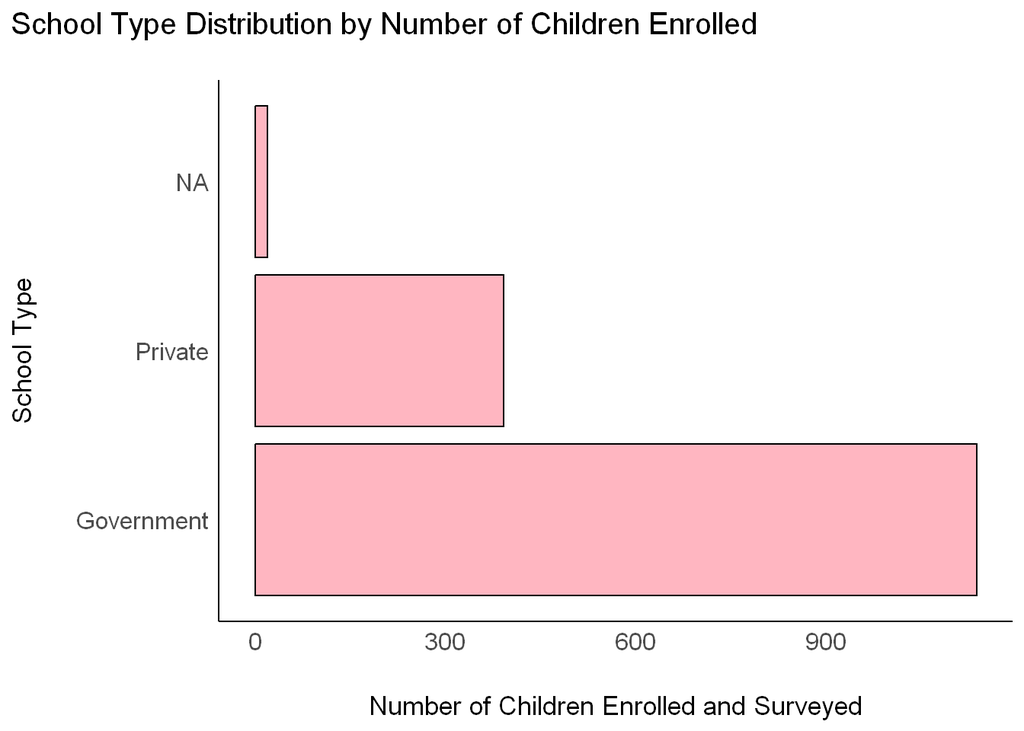

```r
# --- Bar Graph for School Type ---
child_house_school_filtered %>%
  ggplot(aes(x = SchoolType, fill = "ChildrenEnrolled")) +
  geom_bar(fill = "lightpink", color = "black") +
  labs(title = "School Type Distribution by Number of Children Enrolled",
       x = "School Type",
       y = "Number of Children Enrolled and Surveyed") +
  coord_flip() +  # Flips the x and y axes
  theme_modern()
```

### 5.2 Scatter Plot for Children Enrolled vs. Children Present by School Type in Each Rural Region

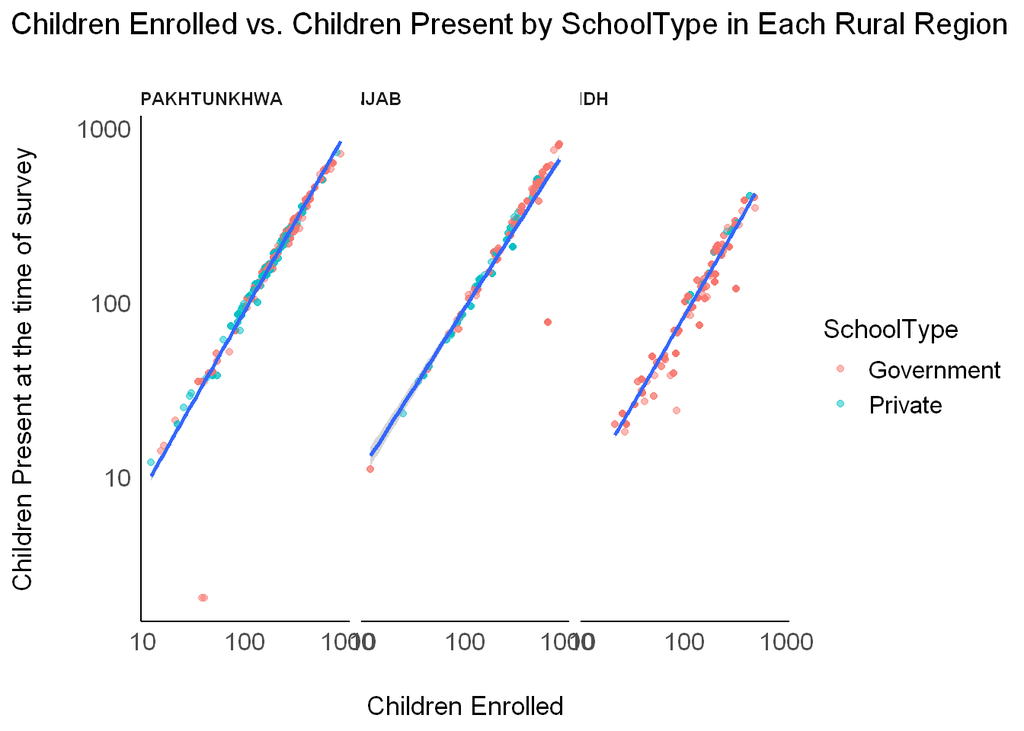

```r
# --- Children Enrolled vs. Children Present by SchoolType in Each Rural Region ---

children_by_school <- child_house_school_filtered %>% #Creating a new variable to manipulate the data easily without affecting the original dataset
  select(RNAME, SchoolType, ChildrenEnrolled, ChildrenPresent) %>%
  filter(ChildrenEnrolled < 900, ChildrenPresent < 900) %>%  # Filter out high values
  filter(!is.na(SchoolType))  # Filter out missing values

children_by_school %>%
  ggplot(aes(x = ChildrenEnrolled, y = ChildrenPresent)) +
  geom_point(aes(color = SchoolType), alpha = 0.5) +
  geom_smooth(method = "lm") + # Adds a linear regression line
  facet_wrap(~ RNAME) +
  scale_x_log10() + # Using log scale for x-axis to allow for wide range of values to be distributed effectively
  scale_y_log10() + # Using log scale for y-axis to allow for wide range of values to be distributed effectively
  labs(title = "Children Enrolled vs. Children Present by SchoolType in Each Rural Region",
       x = "Children Enrolled",
       y = "Children Present at the time of survey") +
  theme_modern()
```

### 5.3 Bar Graph for Students Enrolled in Co-Ed vs Single-Gender Schools

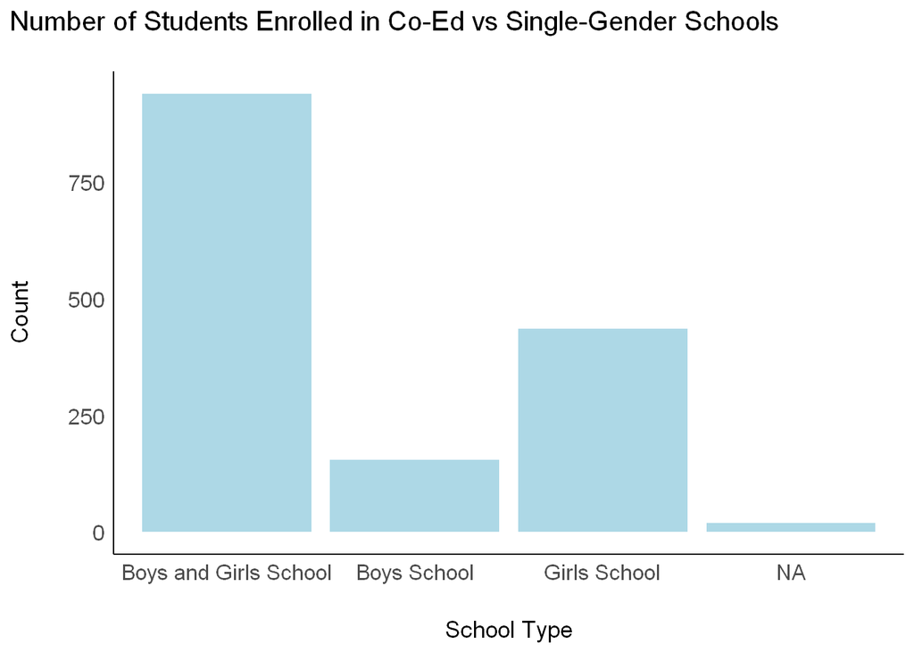

```r
ggplot(child_house_school_filtered, aes(x = SingleOrCoEdSchool)) +
  geom_bar(fill = "lightblue") +
  labs(title = "Number of Students Enrolled in Co-Ed vs Single-Gender Schools", x = "School Type", y = "Count") +
  theme_modern()
```

### 5.4 Bar Graph Showing the Proportion of Psychological Impact by Level of Flood Impact

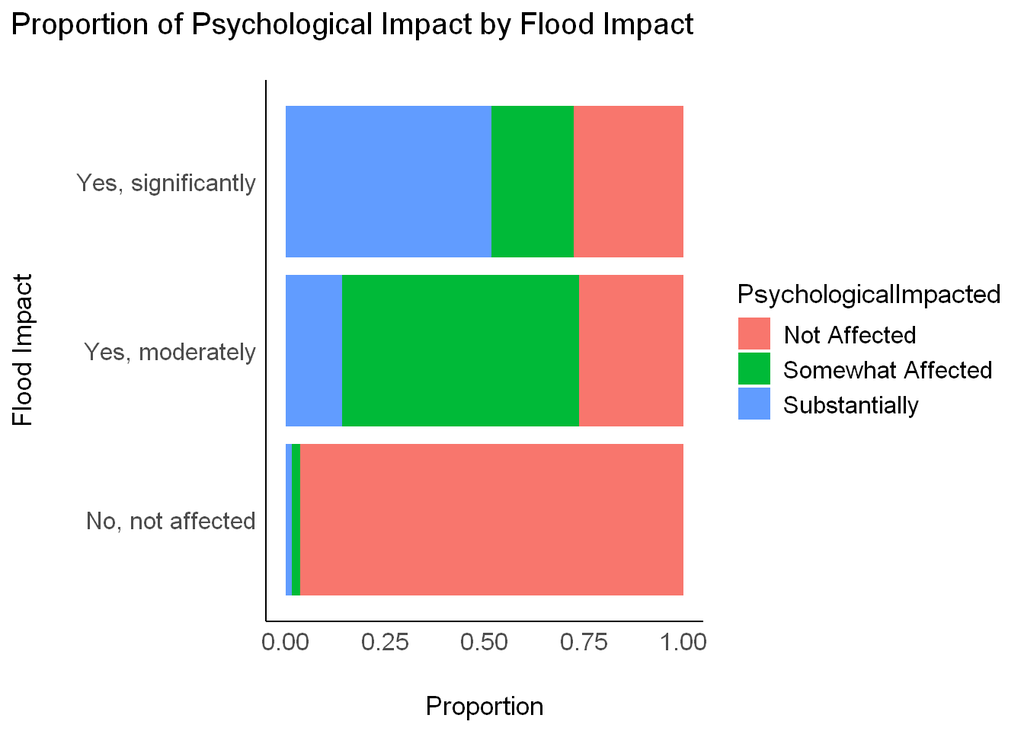

```r
ggplot(child_house_school_filtered, aes(x = FloodImpacted, fill = PsychologicalImpacted)) +
  geom_bar(position = "fill") +  # Creates a stacked bar chart
  coord_flip() +  # Flips the x and y axes
  labs(title = "Proportion of Psychological Impact by Flood Impact", x = "Flood Impact", y = "Proportion") +
  theme_modern()
```

### 5.5 Bar Graph Showing the Proportion of Earning Impacted by Levels of Climate Change Awareness

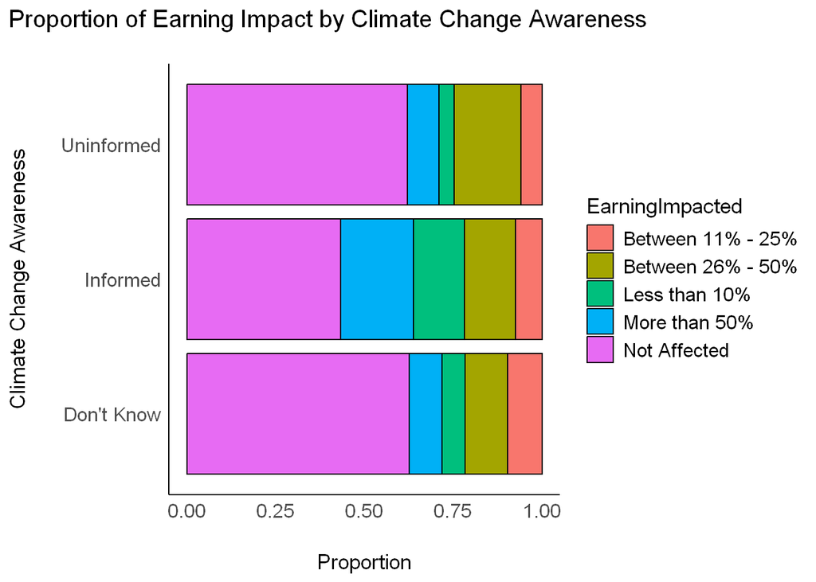

```r
ggplot(child_house_school_filtered, aes(x = ClimateChange, fill = EarningImpacted)) +
  geom_bar(color = "black", position = "fill") +  # Creates a stacked bar chart
  coord_flip() +  # Flips the x and y axes
  labs(title = "Proportion of Earning Impact by Climate Change Awareness", x = "Climate Change Awareness", y = "Proportion") +
  theme_modern()
```

### 5.6 Distribution of Arithmetic Levels by Medium of Instruction for the Primary Grades

[figure not shown]

```r
# Distribution of Arithmetic Levels by Medium of Instruction for the Primary Grades
grade_arithmetic_medium <- child_house_school_filtered %>%
  select(InstructionMedium, ArithmeticLevel, Grades) %>%
  filter(Grades %in% c("Grade 1", "Grade 2", "Grade 3", "Grade 4", "Grade 5")) %>%  # Filter out only the first five grades to focus on primary levels
  filter(InstructionMedium != "Others")  # Filter out the "Others" category
ggplot(grade_arithmetic_medium, aes(x = InstructionMedium, fill = ArithmeticLevel)) +
  geom_bar(color = "black", position = "fill") +  # Stacks the bars proportionally
  facet_wrap(~ Grades) +  # Facets the plot by Grades
  labs(title = "Distribution of Arithmetic Levels by Medium of Instruction for Primary Grades",
       x = "Medium of Instruction (English, Sindhi, Urdu)",
       y = "Proportion of Students Reaching the Arithmetic Level") +
  theme_modern()
```

# 6. Discussion

The bar graph for school type distribution shows that the majority of children are enrolled in government schools compared to private schools. Since the observations are concentrated in rural areas instead of urban, this distribution tends well to the hypothesis that the majority students in rural areas access education through government (public) schools.

The scatter plot for children enrolled vs. children present by school type in each rural region shows that there is a positive correlation between the number of children enrolled and the number of children present in both government and private schools. The linear regression line indicates that as the number of children enrolled increases, the number of children present also increases. This suggests that the schools are able to maintain a good attendance rate for the children enrolled. This is remarkable as it shows that the schools have been resilient in dealing with the after effects of the 2022 floods in Pakistan which resulted in significant impact on the infrastructure of schools, and schooling outcomes of children.

The stacked bar graphs for understanding the relationship between the climate change awareness and the proportion of households experiencing an earning impact, and the flood impact and the proportion of psychological impact, show that there is a significant proportion of households experiencing an earning impact due to climate change. This is a concerning finding as it suggests that the awareness of climate change is not translating into effective policy measures to mitigate the impact on the earning capacity of households. Similarly, the proportion of psychological impact due to flood impact is also significant, which indicates that the psychological well-being of individuals is being affected by the natural disasters in the region.

The distribution of arithmetic levels by the medium of instruction for the primary grades shows that the majority of students are able to reach the arithmetic level of numbers 1-9 in the first five grades. This is a positive finding as it suggests that the students are able to grasp the basic arithmetic concepts in the early grades. However, there is a need to focus on improving the arithmetic levels for the higher grades to ensure that the students are able to build on their foundational knowledge and skills.The performance of schools based on the medium of instruction is also a significant finding as it shows that the students are able to perform comparatively similar in arithmetic for all three major mediums. This goes against the common perception that students perform better in English medium schools compared to Urdu and Sindhi medium schools. However, more research is needed to understand the factors that contribute to the performance of students in different mediums of instruction.